# ProjectPART1 (2)

**Context**

Company X owns a movie application and repository that caters to movie streaming to millions of users on a subscription basis. The company wants to automate the process of cast and crew information in each scene from a movie such that when a user pauses on the movie and clicks on the cast information button, the app will show details of the actor in the scene. The company has in-house computer vision and multimedia experts who need to detect faces from screenshots of the movie scene.

**Objective**

**Part A**

To build a face detection system

**Part B**

To create an image dataset to be used by the AI team to build image classifier data

**Part C**

To build a face recognition system

**Data Dictionary**

**Part A**

label: Identifies the object in the image notes: Additional comments (currently empty) points: Coordinates of the mask (top-left and bottom-right) imageWidth: Width of the image in pixels imageHeight: Height of the image in pixels

**Part B**

The dataset comprises facial images that may contain either multiple individuals or a single individual per image.

**Part C**

This dataset consists of 10,770 images collected from Pinterest, featuring 100 individuals.

```python
import os
import cv2
import keras
import pandas             as pd
import matplotlib.pyplot  as plt
import numpy              as np
import tensorflow         as tf
import pickle

from zipfile import ZipFile
%tensorflow_version 2.x
import tensorflow
tensorflow.__version__
```

```
Colab only includes TensorFlow 2.x; %tensorflow_version has no effect.
```

```
'2.18.0'
```

```python
from google.colab import drive
drive.mount('/content/drive')
```

```python
import os
print(os.listdir("../content"))
```

```
['.config', 'drive', 'sample_data']
```

```python
import numpy as np
data = np.load('/content/drive/MyDrive/Images.npy', allow_pickle=True)
```

```python
data[10][1]
```

```
[{'label': ['Face'],
  'notes': '',
  'points': [{'x': 0.046296296296296294, 'y': 0.16354166666666667},
   {'x': 0.2037037037037037, 'y': 0.2989583333333333}],
  'imageWidth': 648,
  'imageHeight': 960},
 {'label': ['Face'],
  'notes': '',
  'points': [{'x': 0.3194444444444444, 'y': 0.1375},
   {'x': 0.5570987654320988, 'y': 0.29583333333333334}],
  'imageWidth': 648,
  'imageHeight': 960},
 {'label': ['Face'],
  'notes': '',
  'points': [{'x': 0.5648148148148148, 'y': 0.1875},
   {'x': 0.7145061728395061, 'y': 0.30520833333333336}],
  'imageWidth': 648,
  'imageHeight': 960},
 {'label': ['Face'],
  'notes': '',
  'points': [{'x': 0.7160493827160493, 'y': 0.209375},
   {'x': 0.8333333333333334, 'y': 0.30625}],
  'imageWidth': 648,
  'imageHeight': 960},
 {'label': ['Face'],
  'notes': '',
  'points': [{'x': 0.8225308641975309, 'y': 0.23125},
   {'x': 0.9429012345679012, 'y': 0.3177083333333333}],
  'imageWidth': 648,
  'imageHeight': 960}]
```

Setting image dimensions

```python
IMAGE_WIDTH = 224
IMAGE_HEIGHT = 224
```

```python
import cv2
from tensorflow.keras.applications.mobilenet import preprocess_input

masks = np.zeros((int(data.shape[0]), IMAGE_HEIGHT, IMAGE_WIDTH))
X = np.zeros((int(data.shape[0]), IMAGE_HEIGHT, IMAGE_WIDTH, 3))
for index in range(data.shape[0]):
    img = data[index][0]
    img = cv2.resize(img, dsize=(IMAGE_HEIGHT, IMAGE_WIDTH), interpolation=cv2.INTER_CUBIC)
    try:
      img = img[:, :, :3]
    except:
      continue
    X[index] = preprocess_input(np.array(img, dtype=np.float32))
    for i in data[index][1]:
        x1 = int(i["points"][0]['x'] * IMAGE_WIDTH)
        x2 = int(i["points"][1]['x'] * IMAGE_WIDTH)
        y1 = int(i["points"][0]['y'] * IMAGE_HEIGHT)
        y2 = int(i["points"][1]['y'] * IMAGE_HEIGHT)
        masks[index][y1:y2, x1:x2] = 1
```

```python
print("Total number of images in X:", X.shape[0])
print("Total number of masks in y:", masks.shape[0])
```

```
Total number of images in X: 393
Total number of masks in y: 393
```

```python
#Splitting the data into training and testing
# 80% training, 20% testing split
split_ratio = 0.8
split_index = int(split_ratio * X.shape[0])  # 80% of 393

X_train = X[:split_index]
y_train = masks[:split_index]

X_test = X[split_index:]
y_test = masks[split_index:]

print("Training images:", X_train.shape[0])
print("Testing images:", X_test.shape[0])
```

```
Training images: 314
Testing images: 79
```

```python
print("Total images:", X.shape[0])
print("Training images:", X_train.shape[0])
print("Testing images:", X_test.shape[0])
```

```
Total images: 393
Training images: 314
Testing images: 79
```

Printing a sample training image, image array and its mask

```
WARNING:matplotlib.image:Clipping input data to the valid range for imshow with RGB data ([0..1] for floats or [0..255] for integers). Got range [-1.0..1.0].
```

[output not shown]

[figure not shown]

```python
import matplotlib.pyplot as plt

n = 10
print("Image array:", X_train[n])
plt.imshow(X_train[n])
```

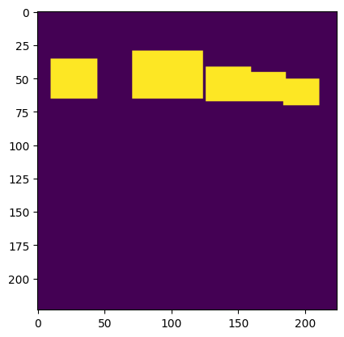

```python
plt.imshow(masks[n])
```

Create the model

```python
from tensorflow.keras.applications.mobilenet import MobileNet
from tensorflow.keras.layers import Reshape, UpSampling2D, Concatenate, Conv2D
from tensorflow.keras.models import Model

def create_model(trainable=True):
    model = MobileNet(input_shape=(IMAGE_HEIGHT, IMAGE_WIDTH, 3), include_top=False, alpha=1.0, weights="imagenet")

    for layer in model.layers:
        layer.trainable = trainable

    block0 = model.get_layer("conv_pw_1_relu").output
    block1 = model.get_layer("conv_pw_3_relu").output
    block2 = model.get_layer("conv_pw_5_relu").output
    block3 = model.get_layer("conv_pw_11_relu").output
    block4 = model.get_layer("conv_pw_13_relu").output

    x = Concatenate()([UpSampling2D()(block4), block3])
    print(x.shape)
    x = Concatenate()([UpSampling2D()(x), block2])
    print(x.shape)
    x = Concatenate()([UpSampling2D()(x), block1])
    print(x.shape)
    x = Concatenate()([UpSampling2D()(x), block0])
    print(x.shape)
    x = UpSampling2D()(x)
    print(x.shape)
    x = Conv2D(1, kernel_size=1, activation="sigmoid")(x)
    x = Reshape((IMAGE_HEIGHT, IMAGE_WIDTH))(x)
    print(x.shape)

    return Model(inputs=model.input, outputs=x)
```

```python
model = create_model()
```

```
Downloading data from https://storage.googleapis.com/tensorflow/keras-applications/mobilenet/mobilenet_1_0_224_tf_no_top.h5
17225924/17225924 ━━━━━━━━━━━━━━━━━━━━ 0s 0us/step
(None, 14, 14, 1536)
(None, 28, 28, 1792)
(None, 56, 56, 1920)
(None, 112, 112, 1984)
(None, 224, 224, 1984)
(None, 224, 224)
```

Printing model summary

```python
model.summary()
```

```
Model: "functional"
```

```
┏━━━━━━━━━━━━━━━━━━━━━━━━━━━┳━━━━━━━━━━━━━━━━━━━━━━━━┳━━━━━━━━━━━━━━━━┳━━━━━━━━━━━━━━━━━━━━━━━━┓
┃ Layer (type)              ┃ Output Shape           ┃        Param # ┃ Connected to           ┃
┡━━━━━━━━━━━━━━━━━━━━━━━━━━━╇━━━━━━━━━━━━━━━━━━━━━━━━╇━━━━━━━━━━━━━━━━╇━━━━━━━━━━━━━━━━━━━━━━━━┩
│ input_layer (InputLayer)  │ (None, 224, 224, 3)    │              0 │ -                      │
├───────────────────────────┼────────────────────────┼────────────────┼────────────────────────┤
│ conv1 (Conv2D)            │ (None, 112, 112, 32)   │            864 │ input_layer[0][0]      │
├───────────────────────────┼────────────────────────┼────────────────┼────────────────────────┤
│ conv1_bn                  │ (None, 112, 112, 32)   │            128 │ conv1[0][0]            │
│ (BatchNormalization)      │                        │                │                        │
├───────────────────────────┼────────────────────────┼────────────────┼────────────────────────┤
│ conv1_relu (ReLU)         │ (None, 112, 112, 32)   │              0 │ conv1_bn[0][0]         │
├───────────────────────────┼────────────────────────┼────────────────┼────────────────────────┤
│ conv_dw_1                 │ (None, 112, 112, 32)   │            288 │ conv1_relu[0][0]       │
│ (DepthwiseConv2D)         │                        │                │                        │
├───────────────────────────┼────────────────────────┼────────────────┼────────────────────────┤
│ conv_dw_1_bn              │ (None, 112, 112, 32)   │            128 │ conv_dw_1[0][0]        │
│ (BatchNormalization)      │                        │                │                        │
├───────────────────────────┼────────────────────────┼────────────────┼────────────────────────┤
│ conv_dw_1_relu (ReLU)     │ (None, 112, 112, 32)   │              0 │ conv_dw_1_bn[0][0]     │
├───────────────────────────┼────────────────────────┼────────────────┼────────────────────────┤
│ conv_pw_1 (Conv2D)        │ (None, 112, 112, 64)   │          2,048 │ conv_dw_1_relu[0][0]   │
├───────────────────────────┼────────────────────────┼────────────────┼────────────────────────┤
│ conv_pw_1_bn              │ (None, 112, 112, 64)   │            256 │ conv_pw_1[0][0]        │
│ (BatchNormalization)      │                        │                │                        │
├───────────────────────────┼────────────────────────┼────────────────┼────────────────────────┤
│ conv_pw_1_relu (ReLU)     │ (None, 112, 112, 64)   │              0 │ conv_pw_1_bn[0][0]     │
├───────────────────────────┼────────────────────────┼────────────────┼────────────────────────┤
│ conv_pad_2                │ (None, 113, 113, 64)   │              0 │ conv_pw_1_relu[0][0]   │
│ (ZeroPadding2D)           │                        │                │                        │
├───────────────────────────┼────────────────────────┼────────────────┼────────────────────────┤
│ conv_dw_2                 │ (None, 56, 56, 64)     │            576 │ conv_pad_2[0][0]       │
│ (DepthwiseConv2D)         │                        │                │                        │
├───────────────────────────┼────────────────────────┼────────────────┼────────────────────────┤
│ conv_dw_2_bn              │ (None, 56, 56, 64)     │            256 │ conv_dw_2[0][0]        │
│ (BatchNormalization)      │                        │                │                        │
├───────────────────────────┼────────────────────────┼────────────────┼────────────────────────┤
│ conv_dw_2_relu (ReLU)     │ (None, 56, 56, 64)     │              0 │ conv_dw_2_bn[0][0]     │
├───────────────────────────┼────────────────────────┼────────────────┼────────────────────────┤
│ conv_pw_2 (Conv2D)        │ (None, 56, 56, 128)    │          8,192 │ conv_dw_2_relu[0][0]   │
├───────────────────────────┼────────────────────────┼────────────────┼────────────────────────┤
```

[output cut: 195 more lines]

```
│ (Concatenate)             │                        │                │ conv_pw_3_relu[0][0]   │
├───────────────────────────┼────────────────────────┼────────────────┼────────────────────────┤
│ up_sampling2d_3           │ (None, 112, 112, 1920) │              0 │ concatenate_2[0][0]    │
│ (UpSampling2D)            │                        │                │                        │
├───────────────────────────┼────────────────────────┼────────────────┼────────────────────────┤
│ concatenate_3             │ (None, 112, 112, 1984) │              0 │ up_sampling2d_3[0][0], │
│ (Concatenate)             │                        │                │ conv_pw_1_relu[0][0]   │
├───────────────────────────┼────────────────────────┼────────────────┼────────────────────────┤
│ up_sampling2d_4           │ (None, 224, 224, 1984) │              0 │ concatenate_3[0][0]    │
│ (UpSampling2D)            │                        │                │                        │
├───────────────────────────┼────────────────────────┼────────────────┼────────────────────────┤
│ conv2d (Conv2D)           │ (None, 224, 224, 1)    │          1,985 │ up_sampling2d_4[0][0]  │
├───────────────────────────┼────────────────────────┼────────────────┼────────────────────────┤
│ reshape (Reshape)         │ (None, 224, 224)       │              0 │ conv2d[0][0]           │
└───────────────────────────┴────────────────────────┴────────────────┴────────────────────────┘
```

```
 Total params: 3,230,849 (12.32 MB)
```

```
 Trainable params: 3,208,961 (12.24 MB)
```

```
 Non-trainable params: 21,888 (85.50 KB)
```

```python
from tensorflow import reduce_sum
from tensorflow.keras.backend import epsilon

def dice_coefficient(y_true, y_pred):
    numerator = 2 * reduce_sum(y_true * y_pred)
    denominator = reduce_sum(y_true + y_pred)
    return numerator / (denominator + epsilon())
```

```python
from tensorflow.keras.losses import binary_crossentropy
from tensorflow.keras.backend import log

def loss(y_true, y_pred):
    return binary_crossentropy(y_true, y_pred) - log(dice_coefficient(y_true, y_pred) + epsilon())
```

```python
model.compile(loss=loss, optimizer='adam', metrics=[dice_coefficient])
```

Using ModelCheckpoint

Using EarlyStopping

Using ReduceLROnPlateau

```python
from tensorflow.keras.callbacks import ModelCheckpoint, EarlyStopping, ReduceLROnPlateau

checkpoint = ModelCheckpoint("model-{loss:.2f}.weights.h5", monitor="loss", verbose=1, save_best_only=True,
                             save_weights_only=True, mode="min")  # Change the filename to end with .weights.h5
stop = EarlyStopping(monitor="loss", patience=5, mode="min")
reduce_lr = ReduceLROnPlateau(monitor="loss", factor=0.2, patience=5, min_lr=1e-6, verbose=1, mode="min")
```

Fitting the model using below parameters epochs: 10 batch_size: 1 callbacks: using the callbacks defined above

```python
# Fitting the model using below parameters epochs: 10 batch_size

history = model.fit(X_train, y_train, epochs=10, batch_size=1, callbacks=[checkpoint, stop, reduce_lr])
```

```
312/314 ━━━━━━━━━━━━━━━━━━━━ 0s 21ms/step - dice_coefficient: 0.4340 - loss: 1.5939
Epoch 1: loss improved from inf to 1.27932, saving model to model-1.28.weights.h5
314/314 ━━━━━━━━━━━━━━━━━━━━ 38s 22ms/step - dice_coefficient: 0.4347 - loss: 1.5909 - learning_rate: 0.0010
312/314 ━━━━━━━━━━━━━━━━━━━━ 0s 22ms/step - dice_coefficient: 0.5672 - loss: 1.0096
Epoch 2: loss improved from 1.27932 to 0.86936, saving model to model-0.87.weights.h5
314/314 ━━━━━━━━━━━━━━━━━━━━ 7s 24ms/step - dice_coefficient: 0.5675 - loss: 1.0083 - learning_rate: 0.0010
313/314 ━━━━━━━━━━━━━━━━━━━━ 0s 23ms/step - dice_coefficient: 0.6741 - loss: 0.6333
Epoch 3: loss improved from 0.86936 to 0.74575, saving model to model-0.75.weights.h5
314/314 ━━━━━━━━━━━━━━━━━━━━ 10s 24ms/step - dice_coefficient: 0.6739 - loss: 0.6340 - learning_rate: 0.0010
313/314 ━━━━━━━━━━━━━━━━━━━━ 0s 22ms/step - dice_coefficient: 0.6984 - loss: 0.5596
Epoch 4: loss improved from 0.74575 to 0.62262, saving model to model-0.62.weights.h5
314/314 ━━━━━━━━━━━━━━━━━━━━ 7s 23ms/step - dice_coefficient: 0.6984 - loss: 0.5600 - learning_rate: 0.0010
313/314 ━━━━━━━━━━━━━━━━━━━━ 0s 22ms/step - dice_coefficient: 0.7073 - loss: 0.5778
Epoch 5: loss improved from 0.62262 to 0.60762, saving model to model-0.61.weights.h5
314/314 ━━━━━━━━━━━━━━━━━━━━ 10s 23ms/step - dice_coefficient: 0.7072 - loss: 0.5780 - learning_rate: 0.0010
313/314 ━━━━━━━━━━━━━━━━━━━━ 0s 22ms/step - dice_coefficient: 0.6825 - loss: 0.6750
Epoch 6: loss did not improve from 0.60762
314/314 ━━━━━━━━━━━━━━━━━━━━ 10s 22ms/step - dice_coefficient: 0.6825 - loss: 0.6747 - learning_rate: 0.0010
314/314 ━━━━━━━━━━━━━━━━━━━━ 0s 21ms/step - dice_coefficient: 0.7269 - loss: 0.5331
Epoch 7: loss improved from 0.60762 to 0.52625, saving model to model-0.53.weights.h5
314/314 ━━━━━━━━━━━━━━━━━━━━ 10s 23ms/step - dice_coefficient: 0.7270 - loss: 0.5331 - learning_rate: 0.0010
314/314 ━━━━━━━━━━━━━━━━━━━━ 0s 22ms/step - dice_coefficient: 0.7714 - loss: 0.4603
Epoch 8: loss improved from 0.52625 to 0.43093, saving model to model-0.43.weights.h5
314/314 ━━━━━━━━━━━━━━━━━━━━ 10s 23ms/step - dice_coefficient: 0.7714 - loss: 0.4602 - learning_rate: 0.0010
313/314 ━━━━━━━━━━━━━━━━━━━━ 0s 22ms/step - dice_coefficient: 0.8016 - loss: 0.3752
Epoch 9: loss improved from 0.43093 to 0.40391, saving model to model-0.40.weights.h5
314/314 ━━━━━━━━━━━━━━━━━━━━ 10s 23ms/step - dice_coefficient: 0.8015 - loss: 0.3754 - learning_rate: 0.0010
312/314 ━━━━━━━━━━━━━━━━━━━━ 0s 23ms/step - dice_coefficient: 0.7927 - loss: 0.3872
Epoch 10: loss improved from 0.40391 to 0.39457, saving model to model-0.39.weights.h5
314/314 ━━━━━━━━━━━━━━━━━━━━ 11s 24ms/step - dice_coefficient: 0.7927 - loss: 0.3872 - learning_rate: 0.0010
```

```
WARNING:matplotlib.image:Clipping input data to the valid range for imshow with RGB data ([0..1] for floats or [0..255] for integers). Got range [-1.0..1.0].
```

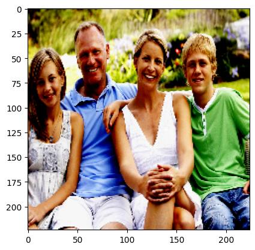

```python
m = 3
plt.imshow(X_test[m])
```

```
WARNING:matplotlib.image:Clipping input data to the valid range for imshow with RGB data ([0..1] for floats or [0..255] for integers). Got range [-1.0..1.0].
```

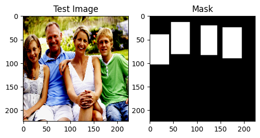

```python
m = 3  # Ensure 0 <= m < len(X_test)

plt.figure(figsize=(6,6))
plt.subplot(1, 2, 1)
plt.imshow(X_test[m])  # Display test image
plt.title("Test Image")

plt.subplot(1, 2, 2)
plt.imshow(y_test[m], cmap="gray")  # Display mask (use grayscale for masks)
plt.title("Mask")

plt.show()
```

Predicting the mask on the test image

```python
m = 3  # Choose an index within range

# Predict mask
pred_mask = model.predict(np.expand_dims(X_test[m], axis=0))[0]

# Convert the predicted mask into binary (thresholding)
threshold = 0.5
pred_mask_binary = (pred_mask > threshold).astype(np.uint8)
```

```
1/1 ━━━━━━━━━━━━━━━━━━━━ 2s 2s/step
```

```
WARNING:matplotlib.image:Clipping input data to the valid range for imshow with RGB data ([0..1] for floats or [0..255] for integers). Got range [-1.0..1.0].
```

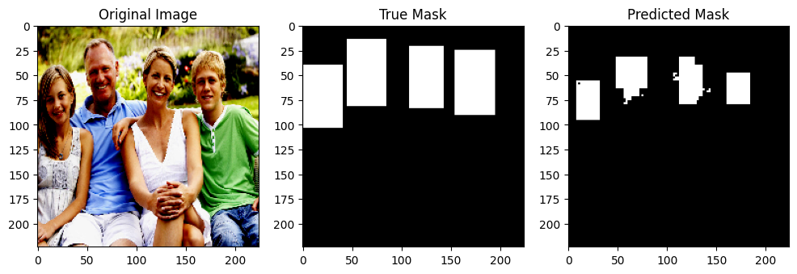

```python
import matplotlib.pyplot as plt

plt.figure(figsize=(12, 4))

# Original Image
plt.subplot(1, 3, 1)
plt.imshow(X_test[m])
plt.title("Original Image")

# True Mask
plt.subplot(1, 3, 2)
plt.imshow(y_test[m], cmap="gray")
plt.title("True Mask")

# Predicted Mask
plt.subplot(1, 3, 3)
plt.imshow(pred_mask_binary, cmap="gray")
plt.title("Predicted Mask")

plt.show()
```

```python
import cv2
kernel = np.ones((5,5), np.uint8)
pred_mask_binary = cv2.morphologyEx(pred_mask_binary, cv2.MORPH_OPEN, kernel)  # Removes small noise
pred_mask_binary = cv2.morphologyEx(pred_mask_binary, cv2.MORPH_CLOSE, kernel) # Fills small holes
```

```python
threshold = 0.3  # Try lowering the threshold
pred_mask_binary = (pred_mask > threshold).astype(np.uint8)
```

```python
from tensorflow.keras.optimizers import Adam

# model with a lower learning rate
model.compile(loss=loss,
              optimizer=Adam(learning_rate=1e-4),
              metrics=[dice_coefficient])
```

```python
from sklearn.model_selection import train_test_split

# Splitting dataset
X_train, X_test, y_train, y_test = train_test_split(X, masks, test_size=0.2, random_state=42)

# Check if the split is correct
print(f"Training images: {len(X_train)}, Testing images: {len(X_test)}")
```

```
Training images: 314, Testing images: 79
```

```python
model.fit(X_train, y_train,
          epochs=20,  # Increase epochs for better training
          batch_size=4,
          callbacks=[checkpoint, reduce_lr, stop],
          validation_data=(X_test, y_test))  # Validate on 79 images
```

[output not shown]

```python
from tensorflow.keras.preprocessing.image import ImageDataGenerator

datagen = ImageDataGenerator(
    rotation_range=20,
    width_shift_range=0.2,
    height_shift_range=0.2,
    horizontal_flip=True
)

train_generator = datagen.flow(X_train, y_train, batch_size=8)
```

```python
from tensorflow.keras.optimizers import Adam

model.compile(optimizer=Adam(learning_rate=1e-5), loss=loss, metrics=[dice_coefficient])
model.fit(X_train, y_train, validation_data=(X_test, y_test), epochs=20, batch_size=8, callbacks=[checkpoint, stop, reduce_lr])
```

```
40/40 ━━━━━━━━━━━━━━━━━━━━ 0s 357ms/step - dice_coefficient: 0.8752 - loss: 0.1942
Epoch 1: loss improved from 0.21060 to 0.20195, saving model to model-0.20.weights.h5
40/40 ━━━━━━━━━━━━━━━━━━━━ 50s 529ms/step - dice_coefficient: 0.8752 - loss: 0.1944 - val_dice_coefficient: 0.8041 - val_loss: 0.3687 - learning_rate: 1.0000e-05
39/40 ━━━━━━━━━━━━━━━━━━━━ 0s 163ms/step - dice_coefficient: 0.8763 - loss: 0.1974
Epoch 2: loss improved from 0.20195 to 0.19923, saving model to model-0.20.weights.h5
40/40 ━━━━━━━━━━━━━━━━━━━━ 7s 184ms/step - dice_coefficient: 0.8762 - loss: 0.1974 - val_dice_coefficient: 0.8043 - val_loss: 0.3683 - learning_rate: 1.0000e-05
39/40 ━━━━━━━━━━━━━━━━━━━━ 0s 164ms/step - dice_coefficient: 0.8783 - loss: 0.1987
Epoch 3: loss did not improve from 0.19923
40/40 ━━━━━━━━━━━━━━━━━━━━ 10s 172ms/step - dice_coefficient: 0.8781 - loss: 0.1987 - val_dice_coefficient: 0.8046 - val_loss: 0.3680 - learning_rate: 1.0000e-05
39/40 ━━━━━━━━━━━━━━━━━━━━ 0s 165ms/step - dice_coefficient: 0.8774 - loss: 0.1988
Epoch 4: loss improved from 0.19923 to 0.19752, saving model to model-0.20.weights.h5
40/40 ━━━━━━━━━━━━━━━━━━━━ 11s 181ms/step - dice_coefficient: 0.8773 - loss: 0.1988 - val_dice_coefficient: 0.8043 - val_loss: 0.3688 - learning_rate: 1.0000e-05
39/40 ━━━━━━━━━━━━━━━━━━━━ 0s 166ms/step - dice_coefficient: 0.8727 - loss: 0.2002
Epoch 5: loss improved from 0.19752 to 0.19585, saving model to model-0.20.weights.h5
40/40 ━━━━━━━━━━━━━━━━━━━━ 10s 182ms/step - dice_coefficient: 0.8729 - loss: 0.2000 - val_dice_coefficient: 0.8048 - val_loss: 0.3679 - learning_rate: 1.0000e-05
39/40 ━━━━━━━━━━━━━━━━━━━━ 0s 165ms/step - dice_coefficient: 0.8742 - loss: 0.1965
Epoch 6: loss did not improve from 0.19585
40/40 ━━━━━━━━━━━━━━━━━━━━ 10s 173ms/step - dice_coefficient: 0.8743 - loss: 0.1966 - val_dice_coefficient: 0.8048 - val_loss: 0.3685 - learning_rate: 1.0000e-05
39/40 ━━━━━━━━━━━━━━━━━━━━ 0s 163ms/step - dice_coefficient: 0.8752 - loss: 0.2002
Epoch 7: loss improved from 0.19585 to 0.19479, saving model to model-0.19.weights.h5
40/40 ━━━━━━━━━━━━━━━━━━━━ 7s 185ms/step - dice_coefficient: 0.8754 - loss: 0.1999 - val_dice_coefficient: 0.8050 - val_loss: 0.3682 - learning_rate: 1.0000e-05
39/40 ━━━━━━━━━━━━━━━━━━━━ 0s 164ms/step - dice_coefficient: 0.8863 - loss: 0.1845
Epoch 8: loss did not improve from 0.19479
40/40 ━━━━━━━━━━━━━━━━━━━━ 10s 172ms/step - dice_coefficient: 0.8859 - loss: 0.1851 - val_dice_coefficient: 0.8051 - val_loss: 0.3687 - learning_rate: 1.0000e-05
39/40 ━━━━━━━━━━━━━━━━━━━━ 0s 165ms/step - dice_coefficient: 0.8819 - loss: 0.1907
Epoch 9: loss did not improve from 0.19479
40/40 ━━━━━━━━━━━━━━━━━━━━ 11s 179ms/step - dice_coefficient: 0.8817 - loss: 0.1909 - val_dice_coefficient: 0.8048 - val_loss: 0.3690 - learning_rate: 1.0000e-05
39/40 ━━━━━━━━━━━━━━━━━━━━ 0s 165ms/step - dice_coefficient: 0.8785 - loss: 0.1986
Epoch 10: loss did not improve from 0.19479
40/40 ━━━━━━━━━━━━━━━━━━━━ 7s 173ms/step - dice_coefficient: 0.8784 - loss: 0.1986 - val_dice_coefficient: 0.8048 - val_loss: 0.3689 - learning_rate: 1.0000e-05
39/40 ━━━━━━━━━━━━━━━━━━━━ 0s 164ms/step - dice_coefficient: 0.8844 - loss: 0.1880
Epoch 11: loss did not improve from 0.19479
40/40 ━━━━━━━━━━━━━━━━━━━━ 10s 173ms/step - dice_coefficient: 0.8841 - loss: 0.1884 - val_dice_coefficient: 0.8049 - val_loss: 0.3693 - learning_rate: 1.0000e-05
39/40 ━━━━━━━━━━━━━━━━━━━━ 0s 167ms/step - dice_coefficient: 0.8781 - loss: 0.1942
Epoch 12: loss improved from 0.19479 to 0.19397, saving model to model-0.19.weights.h5
40/40 ━━━━━━━━━━━━━━━━━━━━ 7s 183ms/step - dice_coefficient: 0.8781 - loss: 0.1942 - val_dice_coefficient: 0.8051 - val_loss: 0.3692 - learning_rate: 1.0000e-05
39/40 ━━━━━━━━━━━━━━━━━━━━ 0s 166ms/step - dice_coefficient: 0.8751 - loss: 0.2023
Epoch 13: loss did not improve from 0.19397
40/40 ━━━━━━━━━━━━━━━━━━━━ 7s 180ms/step - dice_coefficient: 0.8753 - loss: 0.2020 - val_dice_coefficient: 0.8056 - val_loss: 0.3687 - learning_rate: 1.0000e-05
39/40 ━━━━━━━━━━━━━━━━━━━━ 0s 164ms/step - dice_coefficient: 0.8759 - loss: 0.2010
```

[output cut: 20 more lines]

```
<keras.src.callbacks.history.History at 0x7e3cc4946090>
```

Dice Coefficient (Train): 0.8943 → Good! The model is learning.

Loss (Train): 0.1674 → Improving.

```python
# Evaluate the model on the test set
test_loss, test_dice = model.evaluate(X_test, y_test, verbose=1)

print(f"Test Loss: {test_loss:.4f}")
print(f"Test Dice Coefficient: {test_dice:.4f}")
```

```
3/3 ━━━━━━━━━━━━━━━━━━━━ 9s 2s/step - dice_coefficient: 0.8057 - loss: 0.3639
Test Loss: 0.3660
Test Dice Coefficient: 0.8058
```

```
1/1 ━━━━━━━━━━━━━━━━━━━━ 2s 2s/step
```

```
WARNING:matplotlib.image:Clipping input data to the valid range for imshow with RGB data ([0..1] for floats or [0..255] for integers). Got range [-1.0..1.0].
```

[figure not shown]

```python
import matplotlib.pyplot as plt

# Select a test image index
m = 5  # Change this index to view different images

# Get the test image and ground truth mask
test_img = X_test[m]
true_mask = y_test[m]

# Predict the mask
predicted_mask = model.predict(test_img.reshape(1, 224, 224, 3))[0]

# Plot the original image, true mask, and predicted mask
plt.figure(figsize=(12, 4))

# Original Image
plt.subplot(1, 3, 1)
plt.imshow(test_img)
plt.title("Original Image")
plt.axis("off")

# Ground Truth Mask
plt.subplot(1, 3, 2)
plt.imshow(true_mask, cmap="gray")
plt.title("True Mask")
plt.axis("off")

# Predicted Mask
plt.subplot(1, 3, 3)
plt.imshow(predicted_mask, cmap="gray")
plt.title("Predicted Mask")
plt.axis("off")

plt.show()
```

```python
import os

# Path to your Google Drive folder
image_folder = "/content/drive/MyDrive/training_images-20211126T092819Z-001 (1)/training_images"

# Verify the folder exists
if os.path.exists(image_folder):
    print("Folder found!")
else:
    print("Folder NOT found! Check the path.")
```

```
Folder found!
```

```python
from tqdm import tqdm
!pip install opencv-python
import cv2
import os
from tqdm import tqdm
import pandas as pd
```

```python
#Load OpenCV pre-trained face detection model
face_cascade = cv2.CascadeClassifier(cv2.data.haarcascades + "haarcascade_frontalface_default.xml")

# List all images
image_files = [f for f in os.listdir(image_folder) if f.lower().endswith(('.jpg', '.png', '.jpeg'))]
print(f"Total images found: {len(image_files)}")

# Data storage
face_data = []

# Loop through each image
for image_name in tqdm(image_files, desc="Processing Images"):
    img_path = os.path.join(image_folder, image_name)
    img = cv2.imread(img_path)

    if img is None:
        print(f"❌ Skipping {image_name} (Failed to load)")
        continue

    gray = cv2.cvtColor(img, cv2.COLOR_BGR2GRAY)  # Convert to grayscale
    faces = face_cascade.detectMultiScale(gray, scaleFactor=1.1, minNeighbors=5, minSize=(30, 30))

    # Store data for each face
    for (x, y, w, h) in faces:
        face_data.append([image_name, x, y, w, h, len(faces)])

# Convert to DataFrame
df_faces = pd.DataFrame(face_data, columns=['Image', 'X', 'Y', 'Width', 'Height', 'Total_Faces'])

# Save as CSV
csv_path = "/content/drive/MyDrive/faces_metadata.csv"
df_faces.to_csv(csv_path, index=False)

print(f"✅ Face detection complete! Metadata saved at: {csv_path}")
df_faces.head()
```

[output not shown]

```
Total images found: 1091
```